# Reinforcement learning introduction - Challenge

workshop

reinforcement_learning

Reinforcement learning introduction - Frozen Lake example

Published

May 5, 2023

# Reinforcement learning introduction: Frozen Lake example

The Frozen Lake example is a classic reinforcement learning problem, where the goal is to teach an agent to navigate a frozen lake and reach the goal without falling through the ice.

Description:

The Frozen Lake environment is a grid of frozen ice, holes, and a goal, here we will have (4*4) grid size, that’s mean we will have (16 STATES) each cell represent a state.

The agent starts at the top left corner cell in the grid, and can take four actions at each time step, We will have (4 ACTIONS):

- move up
- move down
- move left
- move right

The goal is to reach the goal cell in the bottom right corner of the grid without falling through any holes. Therefore, our REWARDS are:

- If agent current state is a hole state, the reward = -1
- If agent current state is the goal state, the reward = +1
- Else, the reward = 0

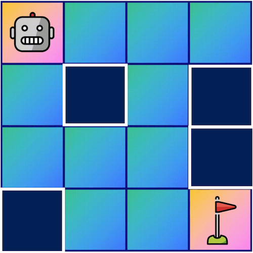

Screen Shot 2023-04-16 at 2.07.26 PM.png

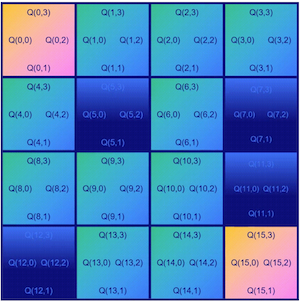

Screen Shot 2023-04-16 at 2.25.49 PM.png

## Import packages and setup your environment

```python
import numpy as np
import random
```

First, we define the FrozenLake environment as a class, with methods for resetting the environment, taking actions, rendering the current state, and showing the current Q-table and policy.

```python
class FrozenLake:
    def __init__(self, size=4):
        self.size = size
        self.grid = np.zeros((4, 4), dtype=int) # spcifiy grid size please
        self.start_state = (0, 0)
        self.goal_state = (3, 3) # can you state the goal state in the grid (row, column)
        self.hole_states = [(1, 1), (2, 3), (3, 0)]
        for i, j in self.hole_states:
            self.grid[i][j] = 1

    def reset(self):
        self.current_state = self.start_state
        return self.current_state

    def step(self, action): # could you please set the actions as numbers
        i, j = self.current_state
        if action == 0: # move up
            i = max(i-1, 0)
        elif action == 1: # move down
            i = min(i+1, self.size-1)
        elif action == 2: # move left
            j = max(j-1, 0)
        elif action == 3: # move right
            j = min(j+1, self.size-1)

        self.current_state = (i, j)

        # what is your rewads?
        if self.current_state == self.goal_state:
            reward = 1 # winning reward?
            done = True
        elif self.current_state in self.hole_states:
            reward = -1 # losing for hole states, reward?
            done = True
        else:
            reward = 0 # else?
            done = False

        return self.current_state, reward, done


    def render(self):
        print('\n')
        for i in range(self.size):
            for j in range(self.size):
                if self.grid[i][j] == 0:
                    if (i, j) == self.current_state:
                        print('S', end=' ')
                    elif (i, j) == self.goal_state:
                        print('G', end=' ')
                    else:
                        print('.', end=' ')
                elif self.grid[i][j] == 1:
                    if (i, j) == self.current_state:
                        print('S', end=' ')
                    else:
                        print('X', end=' ')
            print()
        print()


    def show_q_table(self, q_table):

        print('-----------------------------------------------------------------')
        print('Q-Table:')
        print('-----------------------------------------------------------------')

        for i in range(self.size):
            for j in range(self.size):
                if self.grid[i][j] == 0:
                    print( '%.2f' % q_table[i][j][0], end='\t')
                    print('%.2f' % q_table[i][j][1], end='\t')
                    print('%.2f' % q_table[i][j][2], end='\t')
                    print('%.2f' % q_table[i][j][3])
                else:
                    print('NULL', end='\t')
                    print('NULL', end='\t')
                    print('NULL', end='\t')
                    print('NULL')
            print()


    # In one text line show the policy (the sequence of actions that agent take )
    def show_policy(self, q_table):
        print('\n Policy:')
        for i in range(self.size):
            for j in range(self.size):
                if self.grid[i][j] == 0:
                    action = np.argmax(q_table[i][j])
                    if action == 0:
                        print('UP', end=' ')
                    elif action == 1:
                        print('DOWN', end=' ')
                    elif action == 2:
                        print('LEFT', end=' ')
                    elif action == 3:
                        print('RIGTH', end=' ')
                else:
                    print('STAY', end=' ')
```

Next, we create an instance of the environment and initialize the Q-table with zeros.

```python
env = FrozenLake()
q_table = np.zeros((env.size, env.size, 4))
```